# Distributions homework

Jerry Balloch

# Question 1.

Load the data, clean_names() and explore it.

```r
# read in and clean data
phone_data <- read_csv(here('data/20190928-items.csv')) %>%
  clean_names()
dim(phone_data)
```

```
## [1] 792   9
```

```r
names(phone_data)
```

```
## [1] "asin"          "brand"         "title"         "url"
## [5] "image"         "rating"        "review_url"    "total_reviews"
## [9] "prices"
```

```r
head(phone_data)
```

| asin | brand | title | url | image | rating | review_url | total_reviews | prices |
| --- | --- | --- | --- | --- | --- | --- | --- | --- |
| B0000SX2UC | Nokia | Dual-Band / Tri-Mode Sprint PCS Phone w/ Voice Activated Dialing & Bright White Backlit Screen | https://www.amazon.com/Dual-Band-Tri-Mode-Activated-Dialing-Backlit/dp/B0000SX2UC | https://m.media-amazon.com/images/I/2143EBQ210L._AC_UY218_SEARCH213888_FMwebp_QL75_.jpg | 3.0 | https://www.amazon.com/product-reviews/B0000SX2UC | 14 | NA |
| B0009N5L7K | Motorola | Motorola I265 phone | https://www.amazon.com/Motorola-i265-I265-phone/dp/B0009N5L7K | https://m.media-amazon.com/images/I/419WBAVDARL._AC_UY218_SEARCH213888_FMwebp_QL75_.jpg | 2.9 | https://www.amazon.com/product-reviews/B0009N5L7K | 7 | $49.95 |
| B000SKTZ0S | Motorola | MOTOROLA C168i AT&T CINGULAR PREPAID GOPHONE CELL PHONE | https://www.amazon.com/MOTOROLA-C168i-CINGULAR-PREPAID-GOPHONE/dp/B000SKTZ0S | https://m.media-amazon.com/images/I/71b+q3ydkIS._AC_UY218_SEARCH213888_FMwebp_QL75_.jpg | 2.6 | https://www.amazon.com/product-reviews/B000SKTZ0S | 22 | NA |
| B00198M12M | Nokia | Nokia 6500 Slide Black/silver Unlocked Cell Phone | https://www.amazon.com/Nokia-6500-Slide-silver-Unlocked/dp/B00198M12M | https://m.media-amazon.com/images/I/41ss4HpLkLL._AC_UY218_SEARCH213888_FMwebp_QL75_.jpg | 2.4 | https://www.amazon.com/product-reviews/B00198M12M | 5 | NA |
| B001AO4OUC | Motorola | Motorola i335 Cell Phone Boost Mobile | https://www.amazon.com/Motorola-i335-Phone-Boost-Mobile/dp/B001AO4OUC | https://m.media-amazon.com/images/I/710UO8gdT+L._AC_UY218_SEARCH213888_FMwebp_QL75_.jpg | 3.3 | https://www.amazon.com/product-reviews/B001AO4OUC | 21 | NA |
| B001DCJAJG | Motorola | Motorola V365 no contract cellular phone AT&T | https://www.amazon.com/Motorola-V365-contract-cellular-phone/dp/B001DCJAJG | https://m.media-amazon.com/images/I/61LYNCVrrKL._AC_UY218_SEARCH213888_FMwebp_QL75_.jpg | 3.2 | https://www.amazon.com/product-reviews/B001DCJAJG | 12 | NA |

# Question 2.

Find the brand with the highest numbers of phones in the dataset.

**Answer:** Samsung has the highest number of phones in the dataset at 397.

```r
phone_data %>%
  group_by(brand) %>%
  count() %>%
  arrange(desc(n)) %>%
  head(1)
```

| brand | n |
| --- | --- |
| Samsung | 397 |

# Question 3.

For your top brand, plot the distribution of phone ratings as a probability density, overlaying a fitted normal distribution. Do you think the normal distribution provides a good model of these ratings?

**Answer:** I think the histogram shows a relatively normal distribution, perhaps slightly left-skewed.

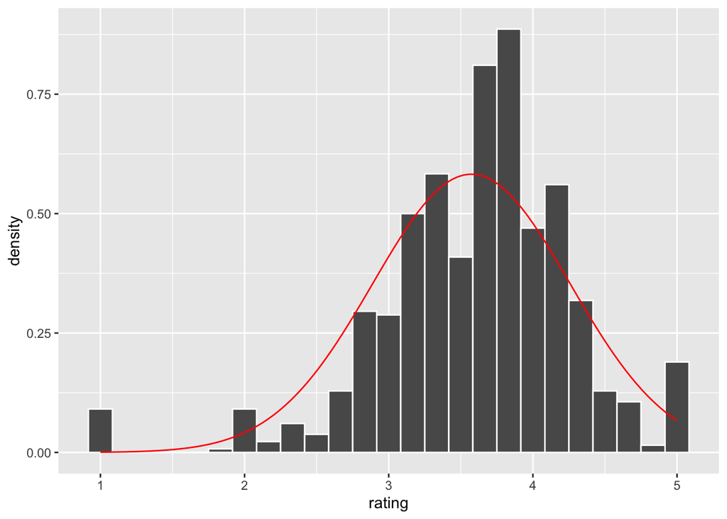

```r
phone_data_stats <- phone_data %>%
  filter(brand == "Samsung") %>%
  summarise(mean_rating = mean(rating),
            sd_rating = sd(rating))

phone_data %>%
  ggplot(aes(x = rating)) +
  geom_histogram(aes(y = ..density..), col = "white", bins = 25) +
  stat_function(
    fun = dnorm,
    args = list(
      mean = phone_data_stats$mean_rating,
      sd = phone_data_stats$sd_rating
    ),
    col = "red"
  )
```

# Question 4.

We can be more quantitative in comparing the distribution of top brand ratings with a normal distribution. You calculated the mean() and sd() of your distribution in an earlier question. Use these values to calculate the proportions of ratings within one-, two- and three standard deviations of the mean. Compare these proportions with those you expect for a normal distribution.

**Answer:** one sd = 79.3%, two sd = 91.9%, three sd = 97.9%  
Normal distribution should be 68% - 95% - 98.7% so we are close on two and three but over on one.

```r
# get the z_score of the ratings column
phones_scaled <-  phone_data %>%
  filter(brand == "Samsung") %>%
  mutate(z_rating = scale(rating))

# calculate proportions of ratings within one standard deviation of the mean
count <- phones_scaled %>%
  filter(between(z_rating, left = -1, right = 1)) %>%
  nrow()

100 * count / nrow(phones_scaled)
```

```
## [1] 79.34509
```

```r
# calculate proportions of ratings within two standard deviation of the mean
count <- phones_scaled %>%
  filter(between(z_rating, left = -2, right = 2)) %>%
  nrow()

100 * count / nrow(phones_scaled)
```

```
## [1] 91.93955
```

```r
# calculate proportions of ratings within three standard deviation of the mean
count <- phones_scaled %>%
  filter(between(z_rating, left = -3, right = 3)) %>%
  nrow()

100 * count / nrow(phones_scaled)
```

```
## [1] 97.98489
```

# 2 Extension

Investigate the use of the qqnorm() plot in R to determine whether data is normally distributed. What is a ‘quantile-quantile plot’? What do we expect to see in a qqnorm() plot if data is nearly normally distributed?

**Answer:** Using qqplot it appears the data has “heavy tails” this indicates the data may have more extreme values than it should if it came from a Normal distribution. A Normal Distribution would have points forming more of a straight line. More along the red line in the plot below.

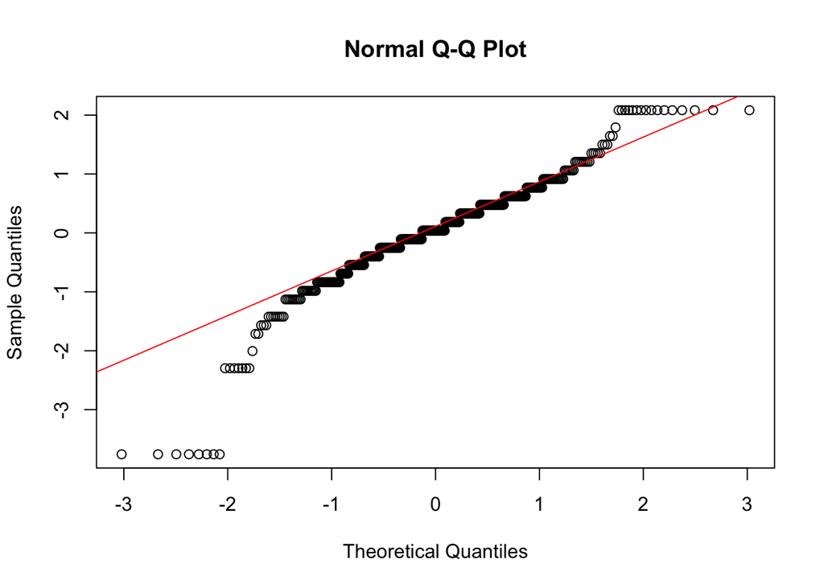

```r
# use `qqnorm` and `qqline`
qqnorm(phones_scaled$z_rating)
qqline(phones_scaled$z_rating, col = "red")
```